# Class Activity

STAT380

```r
###
library(tree)
###
library(ISLR)
#attach(Carseats)
library(rattle)
```

```r
library(rpart.plot)
library(RColorBrewer)
library(partykit)
```

#(Fitting Regression Trees)

### We will use the classification trees for the Boston Housing data

Load the data from the github course page using:

```r
BostonHousing<-read.csv(url("https://raw.githubusercontent.com/subhadippal2019/STAT380UAEU/main/BostonHousing.csv"))
names(BostonHousing)
```

```
##  [1] "CRIM"      "ZN"        "INDUS"     "CHAS"      "NOX"       "RM"
##  [7] "AGE"       "DIS"       "RAD"       "TAX"       "PTRATIO"   "LSTAT"
## [13] "MEDV"      "CAT..MEDV"
```

##Some notations Some notations on the response variable and additional information on Data. Also remove the continuous response, `MEDV' as objective of this activity is to construct a Classification tree on the categorical covariate`CAT..MEDV’

```r
## Classification tree using Boston Housing data:
# Some notation and additional information on Data
head(BostonHousing)
```

```
##      CRIM ZN INDUS CHAS   NOX    RM  AGE    DIS RAD TAX PTRATIO LSTAT MEDV
## 1 0.00632 18  2.31    0 0.538 6.575 65.2 4.0900   1 296    15.3  4.98 24.0
## 2 0.02731  0  7.07    0 0.469 6.421 78.9 4.9671   2 242    17.8  9.14 21.6
## 3 0.02729  0  7.07    0 0.469 7.185 61.1 4.9671   2 242    17.8  4.03 34.7
## 4 0.03237  0  2.18    0 0.458 6.998 45.8 6.0622   3 222    18.7  2.94 33.4
## 5 0.06905  0  2.18    0 0.458 7.147 54.2 6.0622   3 222    18.7  5.33 36.2
## 6 0.02985  0  2.18    0 0.458 6.430 58.7 6.0622   3 222    18.7  5.21 28.7
##   CAT..MEDV
## 1         0
## 2         0
## 3         1
## 4         1
## 5         1
## 6         0
```

```r
str(BostonHousing)
```

```
## 'data.frame':    506 obs. of  14 variables:
##  $ CRIM     : num  0.00632 0.02731 0.02729 0.03237 0.06905 ...
##  $ ZN       : num  18 0 0 0 0 0 12.5 12.5 12.5 12.5 ...
##  $ INDUS    : num  2.31 7.07 7.07 2.18 2.18 2.18 7.87 7.87 7.87 7.87 ...
##  $ CHAS     : int  0 0 0 0 0 0 0 0 0 0 ...
##  $ NOX      : num  0.538 0.469 0.469 0.458 0.458 0.458 0.524 0.524 0.524 0.524 ...
##  $ RM       : num  6.58 6.42 7.18 7 7.15 ...
##  $ AGE      : num  65.2 78.9 61.1 45.8 54.2 58.7 66.6 96.1 100 85.9 ...
##  $ DIS      : num  4.09 4.97 4.97 6.06 6.06 ...
##  $ RAD      : int  1 2 2 3 3 3 5 5 5 5 ...
##  $ TAX      : int  296 242 242 222 222 222 311 311 311 311 ...
##  $ PTRATIO  : num  15.3 17.8 17.8 18.7 18.7 18.7 15.2 15.2 15.2 15.2 ...
##  $ LSTAT    : num  4.98 9.14 4.03 2.94 5.33 ...
##  $ MEDV     : num  24 21.6 34.7 33.4 36.2 28.7 22.9 27.1 16.5 18.9 ...
##  $ CAT..MEDV: int  0 0 1 1 1 0 0 0 0 0 ...
```

```r
BostonHousing$MEDV_Fac = factor(BostonHousing$CAT..MEDV,labels=c("Below","Above"))
BostonHousing$MEDV_Fac
```

```
##   [1] Below Below Above Above Above Below Below Below Below Below Below Below
##  [13] Below Below Below Below Below Below Below Below Below Below Below Below
##  [25] Below Below Below Below Below Below Below Below Below Below Below Below
##  [37] Below Below Below Above Above Below Below Below Below Below Below Below
##  [49] Below Below Below Below Below Below Below Above Below Above Below Below
##  [61] Below Below Below Below Above Below Below Below Below Below Below Below
##  [73] Below Below Below Below Below Below Below Below Below Below Below Below
##  [85] Below Below Below Below Below Below Below Below Below Below Below Below
##  [97] Below Above Above Above Below Below Below Below Below Below Below Below
## [109] Below Below Below Below Below Below Below Below Below Below Below Below
## [121] Below Below Below Below Below Below Below Below Below Below Below Below
## [133] Below Below Below Below Below Below Below Below Below Below Below Below
## [145] Below Below Below Below Below Below Below Below Below Below Below Below
## [157] Below Above Below Below Below Above Above Above Below Below Above Below
## [169] Below Below Below Below Below Below Below Below Below Below Below Above
```

[output cut: 29 more lines]

```r
# As we will be using the MEDV_Fac as categorical response, we will remove both, `CAT..MEDV' and `MEDV' to keep on the required of the data.
BostonH=BostonHousing[,-c(13,14)]
#We will work on the BostonH for rest of the activity
```

### Split the data in Training and Testing Set. Use a 70%/30% split for the Training and Testing Set. Print the dimension of the Testing and the Training set.

```r
#### A5.1:
set.seed(234)
 #inTrain = createDataPartition(Carseats$Sales, p = 0.6, list = FALSE)
  Total_data_size=as.integer(nrow(BostonH))
  inTrain = sample(1:Total_data_size, round(Total_data_size*0.70))
  Training_Set = BostonH[inTrain, ]
  dim(Training_Set)
```

```
## [1] 354  13
```

```r
  Testing_Set<-BostonH[-inTrain, ]
  dim(Testing_Set)
```

```
## [1] 152  13
```

```r
  names(BostonH)
```

```
##  [1] "CRIM"     "ZN"       "INDUS"    "CHAS"     "NOX"      "RM"
##  [7] "AGE"      "DIS"      "RAD"      "TAX"      "PTRATIO"  "LSTAT"
## [13] "MEDV_Fac"
```

### Fitting a classification Tree

We Fit a classification tree on the Training Set using the response `MEDV_Fac’, the median price of houses in a region, as the response variable while all the other variables. We also Display/plot the fitted tree.

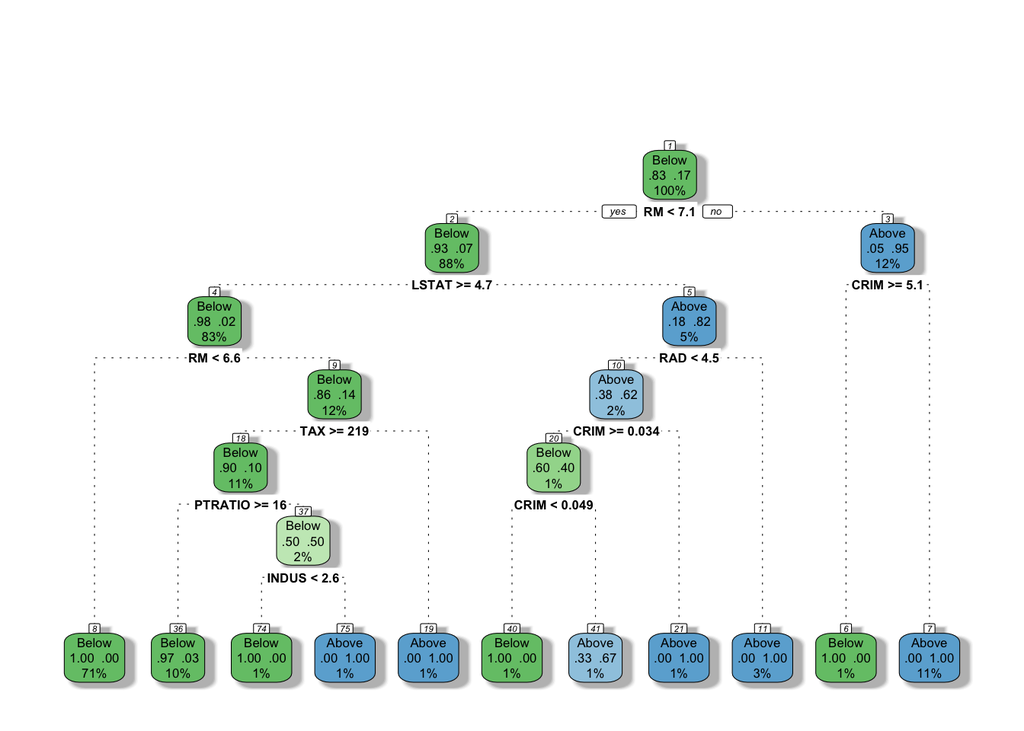

```r
#-------------------------------------
# Grow a general classification tree with multiple covariates
# - minimum number of units that exists in a node in order for a split to be attempted
# - change complexity parameter alpha to -1 - full tree
set.seed(12043)
cls_fit_train = rpart(MEDV_Fac~CRIM+ZN+INDUS+CHAS+NOX+RM+AGE+DIS+RAD+TAX+PTRATIO+LSTAT,data=Training_Set,method="class",minsplit=5,cp=0)

# plot fitted tree# You may use fancyRpartPlot(fitted_object, caption = NULL)
fancyRpartPlot(cls_fit_train, caption = NULL)
```

### Print the summary and the tables containig the crossvalidated ``` cp' and plot the `crossvalidated ``cp’. (summary, printcp, plotcp) We also, identify an optimal value for the complexity parameter `cp’.

```r
summary(cls_fit_train)
```

```
## Call:
## rpart(formula = MEDV_Fac ~ CRIM + ZN + INDUS + CHAS + NOX + RM +
##     AGE + DIS + RAD + TAX + PTRATIO + LSTAT, data = Training_Set,
##     method = "class", minsplit = 5, cp = 0)
##   n= 354
##
##           CP nsplit  rel error    xerror       xstd
## 1 0.62295082      0 1.00000000 1.0000000 0.11648426
## 2 0.18032787      1 0.37704918 0.5409836 0.08967637
## 3 0.03278689      2 0.19672131 0.3442623 0.07286187
## 4 0.01639344      3 0.16393443 0.2786885 0.06594896
## 5 0.01092896      7 0.08196721 0.3278689 0.07121259
## 6 0.00000000     10 0.04918033 0.3278689 0.07121259
##
## Variable importance
##      RM   LSTAT PTRATIO      ZN   INDUS    CRIM     NOX     TAX     RAD     DIS
##      35      25       8       6       5       5       5       4       4       2
##     AGE
##       1
##
## Node number 1: 354 observations,    complexity param=0.6229508
##   predicted class=Below  expected loss=0.1723164  P(node) =1
##     class counts:   293    61
##    probabilities: 0.828 0.172
##   left son=2 (312 obs) right son=3 (42 obs)
##   Primary splits:
##       RM      < 7.0835   to the left,  improve=57.99480, (0 missing)
##       LSTAT   < 5.055    to the right, improve=53.34461, (0 missing)
##       INDUS   < 3.985    to the right, improve=27.06907, (0 missing)
##       PTRATIO < 17.85    to the right, improve=17.20158, (0 missing)
##       ZN      < 15       to the left,  improve=12.82695, (0 missing)
##   Surrogate splits:
##       LSTAT   < 4.475    to the right, agree=0.921, adj=0.333, (0 split)
##       PTRATIO < 14.55    to the right, agree=0.898, adj=0.143, (0 split)
##       ZN      < 87.5     to the left,  agree=0.890, adj=0.071, (0 split)
##       INDUS   < 1.605    to the right, agree=0.887, adj=0.048, (0 split)
##
## Node number 2: 312 observations,    complexity param=0.1803279
##   predicted class=Below  expected loss=0.06730769  P(node) =0.8813559
##     class counts:   291    21
```

[output cut: 186 more lines]

```
##
## Node number 41: 3 observations
##   predicted class=Above  expected loss=0.3333333  P(node) =0.008474576
##     class counts:     1     2
##    probabilities: 0.333 0.667
##
## Node number 74: 3 observations
##   predicted class=Below  expected loss=0  P(node) =0.008474576
##     class counts:     3     0
##    probabilities: 1.000 0.000
##
## Node number 75: 3 observations
##   predicted class=Above  expected loss=0  P(node) =0.008474576
##     class counts:     0     3
##    probabilities: 0.000 1.000
```

```r
printcp(cls_fit_train)
```

```
##
## Classification tree:
## rpart(formula = MEDV_Fac ~ CRIM + ZN + INDUS + CHAS + NOX + RM +
##     AGE + DIS + RAD + TAX + PTRATIO + LSTAT, data = Training_Set,
##     method = "class", minsplit = 5, cp = 0)
##
## Variables actually used in tree construction:
## [1] CRIM    INDUS   LSTAT   PTRATIO RAD     RM      TAX
##
## Root node error: 61/354 = 0.17232
##
## n= 354
##
##         CP nsplit rel error  xerror     xstd
## 1 0.622951      0  1.000000 1.00000 0.116484
## 2 0.180328      1  0.377049 0.54098 0.089676
## 3 0.032787      2  0.196721 0.34426 0.072862
## 4 0.016393      3  0.163934 0.27869 0.065949
## 5 0.010929      7  0.081967 0.32787 0.071213
## 6 0.000000     10  0.049180 0.32787 0.071213
```

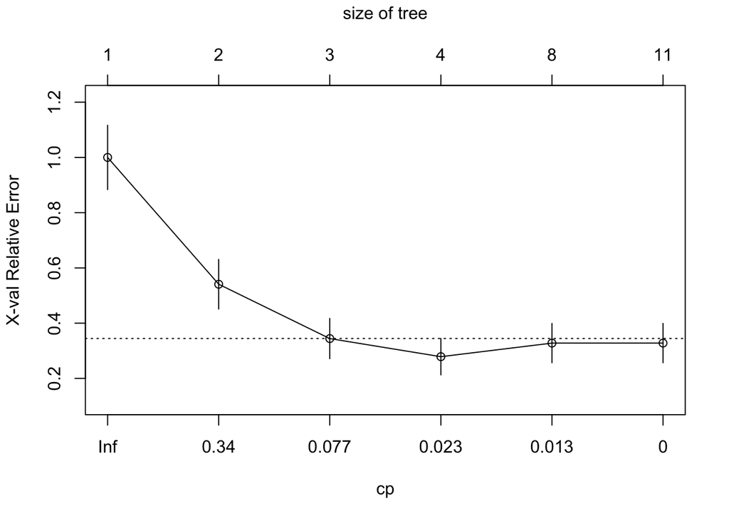

```r
plotcp(cls_fit_train)
```

```r
## B4.
bestcp <-cls_fit_train$cptable[which.min(cls_fit_train$cptable[,"xerror"]),"CP"]
```

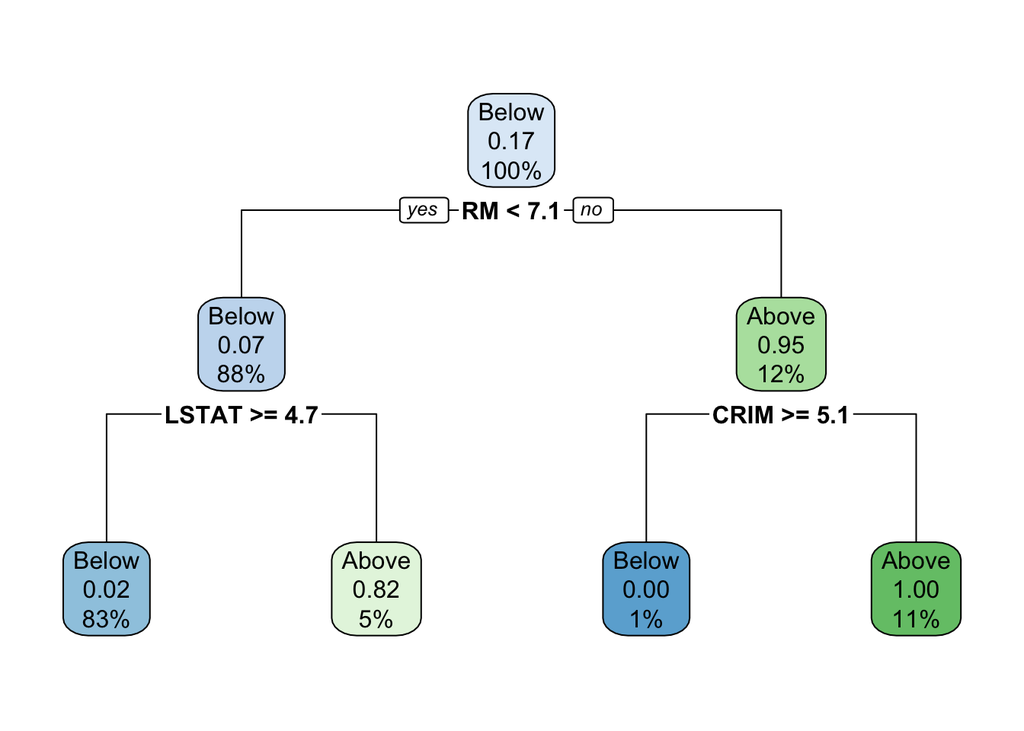

```r
#bestcp <-fit_train$cptable[which.min(fit_train$cptable[,"xerror"]),"CP"]
cls_pruned.tree <- prune(cls_fit_train, cp = bestcp)
rpart.plot(cls_pruned.tree)
```

###

```r
##Predict:
cls_pred_test.prune_prob = predict(cls_pruned.tree, Testing_Set)

cls_pred_test.prune = predict(cls_pruned.tree, Testing_Set, type="class")

###
cls_pred_test.full_tree=predict(cls_fit_train, Testing_Set, main="Entire Tree on Trainig Set", type="class")
```

### Create A classification Tables of the errors using both the Predicted values from the pruned tree and the entire tree fitted using the training set.

### Compare the classification performance of the tree and the pruned tree.

```r
#A9.1
table(cls_pred_test.prune ,Testing_Set$MEDV_Fac )
```

```
##
## cls_pred_test.prune Below Above
##               Below   124     6
##               Above     5    17
```

```r
#A9.2
table(cls_pred_test.full_tree,Testing_Set$MEDV_Fac )
```

```
##
## cls_pred_test.full_tree Below Above
##                   Below   124     3
##                   Above     5    20
```